# SnowFinse - Dryas phenology

Author

Ruben Erik Roos

## About this document

This site presents code to produce figures and analyses as reported by Roos et al., A year without summer: how mid-summer cold affects flowering phenology and reduces seed production of Dryas octopetala.

It includes scripts for data analyses of climate data recorded at the official weather stations at Finse (Norway), microclimate data recorded at Mt. Sanddalsnuten (Finse, Norway), and phenological data on Dryas octopetala collected with time-lapse cameras at Mt. Sanddalsnuten.

## Load packages

Load required packages.

```r
library(tidyverse)
library(zoo)
library(dplyr)
library(cowplot)
library(readr)
library(viridis)
```

## Load datafiles

Climate and weather data from Finse are publicly availabe at: seklima.met.no

```r
#Load the data required for the July temperature analyses for the Finse weather stations.
temp_july<- read.csv("Data/July_temperatures_Finse.csv", sep = ";", header = TRUE)

#Load the data required for daily temperature analyses
temp_daily <- read.csv("Data/All_weather_parameters_Finse2.csv", sep = ";", header = TRUE)

#Load all dates for temperature recordings (dates without data are not printed by the seklima.met.no database)
all_dates <- read.csv("Data/All_dates_Finse.csv", sep = ";", header = TRUE)


#Load the seed count data
df_seed<- readxl::read_xlsx("Data/2020_Dryas flowering and seed set.xlsx")
```

## July temperature analysis

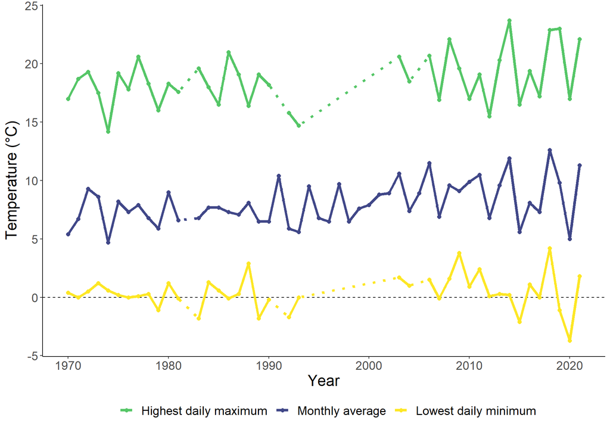

Figure 1: Maximum daily, minimum daily, and monthly mean temperatures for July at Finse, Norway

```r
#Convert data to long format
temp_july_long <- gather(temp_july, variable, temperature, TAM_july:TAX_july, factor_key=TRUE)
temp_july_long$variable <- factor(temp_july_long$variable, levels = c("TAX_july", "TAM_july", "TAN_july"))

#Create plot
p.july <- ggplot(temp_july_long, aes(x = Year, y = temperature, col = variable)) +
  geom_hline(yintercept = 0, linetype = "dashed")+
  geom_point(size= 2) +
  geom_line(linewidth = 1.5)+
  geom_line(data = filter(temp_july_long, is.na(temperature)==FALSE), linetype = "dotted", linewidth = 1.5) +
  scale_color_manual(values=c('#55C667FF', '#404788FF', '#FDE725FF'), labels = c( "Highest daily maximum","Monthly average", "Lowest daily minimum"))+
  theme_classic()+
  theme(legend.position="bottom") +
  theme(legend.title = element_blank()) +
  xlab(expression("Year"))+
  ylab(expression("Temperature (\u00b0C)"))+
  theme(text = element_text(size=18))

p.july
```

## Daily temperature analyses: calculating yearly thawing degree days

First, we need to clean the data somewhat.

```r
all_dates <- all_dates %>%
  mutate(Date=as.Date(Date, format = "%d.%m.%Y")) #converts to proper date format
temp_daily <- temp_daily %>%
  mutate(Date=as.Date(Date, format = "%d.%m.%Y")) #converts to proper date format


#Now join to the dataframe with all dates

temp_daily <- all_dates %>% left_join(., temp_daily, by = "Date")


#Data format and prep
temp_daily <- temp_daily %>%
  mutate(Year = as.numeric(format(Date,'%Y')))%>% #adds column with year
  mutate(Month = as.numeric(format(Date, '%m'))) %>% #adds column with month
  mutate(Jday = as.numeric(format(Date, '%j'))) %>% #adds column with Julian day (day of year)
  mutate(RR = "is.na<-"(RR, RR < 0)) %>% #convert missing or negative precipitation to NA
  mutate(TAM = "is.na<-"(TAM, TAM == -99.9), TAN = "is.na<-"(TAN, TAN == -99.9), TAX = "is.na<-"(TAX, TAX == -99.9)) %>% #convert missing TAM, TAN, and TAX to NA.
  mutate(TAM = "is.na<-"(TAM, TAM =="-"), TAN = "is.na<-"(TAN, TAN == "-"), TAX = "is.na<-"(TAX, TAX == "-"), RR = "is.na<-"(RR, RR == "-")) %>% #recently, missing values have been reported as "-" by seklima, this line converts also those to NA
  mutate(TAM = as.numeric(TAM), TAN = as.numeric(TAN), TAX = as.numeric(TAX), RR = as.numeric(RR))


#Where the daily average is missing, we can substitute by the average of the daily minimum and maximum, if these values are available.
temp_daily <- temp_daily %>%
  mutate(TAM= ifelse(is.na(TAM), (TAN+TAX)/2, TAM))
```

Because some years are missing a lot of data, we have to remove these years. In this case, if more than ten days have missing data for daily average temperature, that year is removed from the dataset.

```r
complete_season_TDD10 <- temp_daily %>%
  group_by(Year) %>%
  dplyr::summarise(count = sum(!is.na(TAM))) %>%
  filter(count >=355) %>%
  pull(Year) #here we select the years that have sufficient data

temp_daily_year10 <-  temp_daily%>%
  filter(Year %in% complete_season_TDD10)# here is where select only the complete seasons

#This removed years 1969, 1982, 1991, 1992, 1994-2002, and 2017

TDD_yearly_summed <- temp_daily_year10 %>%
  group_by(Year) %>%
  mutate(TDD = if_else(TAM >= 0, TAM-0, 0)) %>%
  dplyr::summarize(TDD_sum = sum(TDD, na.rm = TRUE)) #calculates thawing degree days per year
```

Calculate which years are outliers

```r
TDD_yearly_summary <- TDD_yearly_summed %>%
  summarise_at(vars(TDD_sum),
               list(min=min,
                    Q1=~quantile(., probs = 0.25),
                    median=median,
                    mean=mean,
                    Q3=~quantile(., probs = 0.75),
                    max=max,
                    IQR = IQR,
                    upper_limit = ~quantile(., probs = 0.75) + 1.5 * IQR,
                    lower_limit = ~quantile(., probs = 0.25)- 1.5 * IQR,
                    sd = ~sd(.),
                    se = ~sd(./sqrt(.))))

TDD_yearly_summary
```

```
# A tibble: 1 × 11
    min    Q1 median  mean    Q3   max   IQR upper_limit lower_limit    sd    se
  <dbl> <dbl>  <dbl> <dbl> <dbl> <dbl> <dbl>       <dbl>       <dbl> <dbl> <dbl>
1  623.  751.   805.  866.  986. 1210.  236.       1340.        397.  168.  2.79
```

We can now make figures

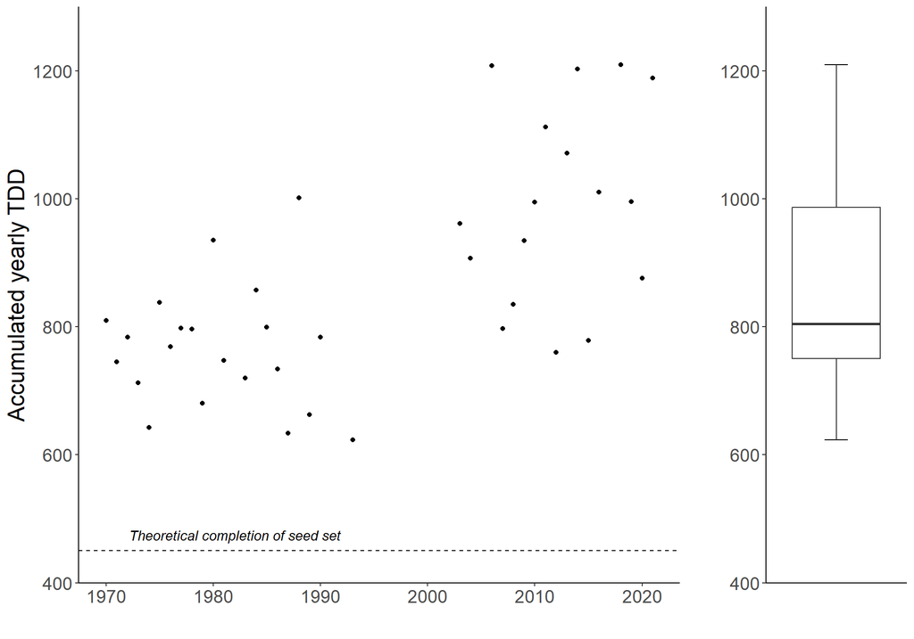

```r
#| warning: false
#| label: fig-julytemps
#| fig-cap: "Yearly accumulated thawing degree days at Finse, Norway. Note that data collected between 1969 and 1992 and after 2004 are collected from different weather stations, see Roos et al. 2022. The theoretical completion of seed set is based on Semenchuck et al. 2016"
#|fig-width: 10
#|fig-height: 8

#Create plot

p.yearly.tdd <- ggplot(data = TDD_yearly_summed, aes(x = Year, y = TDD_sum))+
  geom_point() +
  geom_hline(yintercept=450, linetype = "dashed")+
  theme_classic()+
  labs(y = "Accumulated yearly TDD", x = "Year")+
  theme(text = element_text(size=18), axis.title.x=element_blank()) +
  annotate("text", x = 1982, y = 475, label = "Theoretical completion of seed set", fontface= "italic")+
  scale_y_continuous(expand = c(0, 0), limits = c(400, 1300))

#create accompanying boxplot

p.yearly.tdd.box <- ggplot(data = TDD_yearly_summed, aes(x=factor(0), y = TDD_sum)) +
  stat_boxplot(geom = 'errorbar', width = 0.2)+
  geom_boxplot() +
  theme_classic()+
  labs(x = "", y = "") +
  theme(axis.ticks.x=element_blank(), axis.text.x=element_blank(), axis.title.y=element_blank(), text = element_text(size = 18)) +
  scale_y_continuous(expand = c(0, 0), limits = c(400, 1300)) +
  geom_text(data=subset(TDD_yearly_summed, TDD_sum > 1340), #1340 is the upper outlier limit as calculated above
            aes(factor(0),TDD_sum, label=Year))

#create one plot
p.TDD.yearly <- plot_grid(p.yearly.tdd, p.yearly.tdd.box, ncol =2, rel_widths = c(1,0.33), align = "hv")
p.TDD.yearly
```